# Neural Networks with Keras: IMDB Movie Review

Stat 542, F18

## Rstudio AMI

Use AMI from http://www.louisaslett.com/RStudio_AMI/. Pick p2.xlarge.

Setup GPU for Keras.

```r
# install.packages("keras")
library("keras")
install_keras(tensorflow = "gpu")
```

## Load Libraries

```r
library(keras)
library(dplyr)
```

```r
library(ggplot2)
library(pROC)
```

https://keras.rstudio.com/articles/tutorial_basic_text_classification.html

### Load Data

```r
imdb <- dataset_imdb(num_words = 10000)
c(train_data, train_labels) %<-% imdb$train
c(test_data, test_labels) %<-% imdb$test
```

Check the keras page to understand how data are stored.

```r
library(purrr)  # for the map function
word_index <- dataset_imdb_word_index()
word_index_df <- data.frame(
  word = names(word_index),
  idx = unlist(word_index, use.names = FALSE),
  stringsAsFactors = FALSE
)

# The first indices are reserved
word_index_df <- word_index_df %>% mutate(idx = idx + 3)
word_index_df <- word_index_df %>%
  add_row(word = "<PAD>", idx = 0)%>%
  add_row(word = "<START>", idx = 1)%>%
  add_row(word = "<UNK>", idx = 2)%>%
  add_row(word = "<UNUSED>", idx = 3)

word_index_df <- word_index_df %>% arrange(idx)

decode_review <- function(text){
  paste(map(text, function(number) word_index_df %>%
              filter(idx == number) %>%
              select(word) %>%
              pull()),
        collapse = " ")
}
decode_review(train_data[[1]])
```

```
## [1] "<START> this film was just brilliant casting location scenery story direction everyone's really suited the part they played and you could just imagine being there robert <UNK> is an amazing actor and now the same being director <UNK> father came from the same scottish island as myself so i l…
```

Each review needs to be converted into a numerical vector. We considered two approaches:

### Approach I: Pre-processing

```r
vectorize_sequences <- function(sequences, dimension = 10000) {
  results <- matrix(0, nrow = length(sequences), ncol = dimension)
  for (i in 1:length(sequences))
    results[i, sequences[[i]]] <- 1
  results
}

x_train <- vectorize_sequences(train_data)
x_test <- vectorize_sequences(test_data)
```

### Approach I: Specify Network Architecture

```r
model1 <- keras_model_sequential() %>%
  layer_dense(units = 16, activation = "relu", input_shape = c(10000)) %>%
  layer_dense(units = 16, activation = "relu") %>%
  layer_dense(units = 1, activation = "sigmoid")

summary(model1)
```

```
## ___________________________________________________________________________
## Layer (type)                     Output Shape                  Param #
## ===========================================================================
## dense_1 (Dense)                  (None, 16)                    160016
## ___________________________________________________________________________
## dense_2 (Dense)                  (None, 16)                    272
## ___________________________________________________________________________
## dense_3 (Dense)                  (None, 1)                     17
## ===========================================================================
## Total params: 160,305
## Trainable params: 160,305
## Non-trainable params: 0
## ___________________________________________________________________________
```

### Approach I: Specify Loss Function and Optimizer

```r
model1 %>% compile(
  optimizer = "rmsprop",
  loss = "binary_crossentropy",
  metrics = c("accuracy")
)
```

### Approach I: Model Fitting and Evaluation

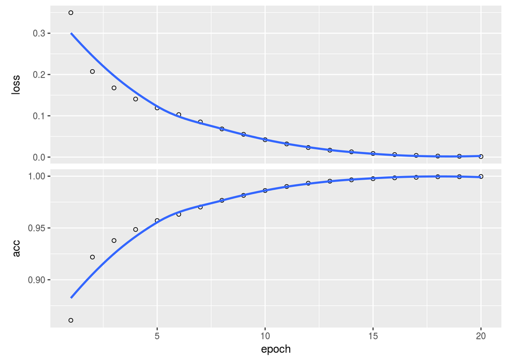

```r
history <- model1 %>%
  fit(x_train, train_labels, epochs = 20, batch_size = 128)
plot(history)
```

```r
predictions <- model1 %>% predict(x_test)
table(test_labels, predictions>0.5)
```

```
##
## test_labels FALSE  TRUE
##           0 10149  2351
##           1  1592 10908
```

```r
roc(test_labels, as.vector(predictions))
```

```
##
## Call:
## roc.default(response = test_labels, predictor = as.vector(predictions))
##
## Data: as.vector(predictions) in 12500 controls (test_labels 0) < 12500 cases (test_labels 1).
## Area under the curve: 0.9054
```

### Approach II: Pre-processing

```r
train_data_x <- pad_sequences(
  train_data,
  value = word_index_df %>% filter(word == "<PAD>") %>% select(idx) %>% pull(),
  padding = "post",
  maxlen = 256
)

test_data_x <- pad_sequences(
  test_data,
  value = word_index_df %>% filter(word == "<PAD>") %>% select(idx) %>% pull(),
  padding = "post",
  maxlen = 256
)
```

Check the training and test data sets.

```r
dim(train_data_x)
```

```
## [1] 25000   256
```

```r
dim(test_data_x)
```

```
## [1] 25000   256
```

```r
train_data_x[1, ]
```

```
##   [1]    1   14   22   16   43  530  973 1622 1385   65  458 4468   66 3941
##  [15]    4  173   36  256    5   25  100   43  838  112   50  670    2    9
##  [29]   35  480  284    5  150    4  172  112  167    2  336  385   39    4
##  [43]  172 4536 1111   17  546   38   13  447    4  192   50   16    6  147
##  [57] 2025   19   14   22    4 1920 4613  469    4   22   71   87   12   16
##  [71]   43  530   38   76   15   13 1247    4   22   17  515   17   12   16
##  [85]  626   18    2    5   62  386   12    8  316    8  106    5    4 2223
##  [99] 5244   16  480   66 3785   33    4  130   12   16   38  619    5   25
## [113]  124   51   36  135   48   25 1415   33    6   22   12  215   28   77
## [127]   52    5   14  407   16   82    2    8    4  107  117 5952   15  256
## [141]    4    2    7 3766    5  723   36   71   43  530  476   26  400  317
## [155]   46    7    4    2 1029   13  104   88    4  381   15  297   98   32
## [169] 2071   56   26  141    6  194 7486   18    4  226   22   21  134  476
## [183]   26  480    5  144   30 5535   18   51   36   28  224   92   25  104
## [197]    4  226   65   16   38 1334   88   12   16  283    5   16 4472  113
## [211]  103   32   15   16 5345   19  178   32    0    0    0    0    0    0
## [225]    0    0    0    0    0    0    0    0    0    0    0    0    0    0
## [239]    0    0    0    0    0    0    0    0    0    0    0    0    0    0
## [253]    0    0    0    0
```

```r
train_data[[1]]
```

```
##   [1]    1   14   22   16   43  530  973 1622 1385   65  458 4468   66 3941
##  [15]    4  173   36  256    5   25  100   43  838  112   50  670    2    9
##  [29]   35  480  284    5  150    4  172  112  167    2  336  385   39    4
##  [43]  172 4536 1111   17  546   38   13  447    4  192   50   16    6  147
##  [57] 2025   19   14   22    4 1920 4613  469    4   22   71   87   12   16
##  [71]   43  530   38   76   15   13 1247    4   22   17  515   17   12   16
##  [85]  626   18    2    5   62  386   12    8  316    8  106    5    4 2223
##  [99] 5244   16  480   66 3785   33    4  130   12   16   38  619    5   25
## [113]  124   51   36  135   48   25 1415   33    6   22   12  215   28   77
## [127]   52    5   14  407   16   82    2    8    4  107  117 5952   15  256
## [141]    4    2    7 3766    5  723   36   71   43  530  476   26  400  317
## [155]   46    7    4    2 1029   13  104   88    4  381   15  297   98   32
## [169] 2071   56   26  141    6  194 7486   18    4  226   22   21  134  476
## [183]   26  480    5  144   30 5535   18   51   36   28  224   92   25  104
## [197]    4  226   65   16   38 1334   88   12   16  283    5   16 4472  113
## [211]  103   32   15   16 5345   19  178   32
```

### Approach II: Specify Network Architecture

Our input data are first fed into an embedding layer, which maps each word in the vocabulary (`vocab_size = 10000`) to a vector of length 16 (`output_dim = 16`). Then each review, which has 256 words, is represented by a 256-by-16 matrix. Obtain the column mean of that mtarix by applying `layer_global_average_pooling_1d()`. Finally each review is represented by a 16x1 numerical vector, which is then fed into a fully connected layer with 16 hidden units.

```r
vocab_size <- 10000

model2 <- keras_model_sequential() %>%
  layer_embedding(input_dim = vocab_size, output_dim = 16) %>%
  layer_global_average_pooling_1d() %>%
  layer_dense(units = 16, activation = "relu") %>%
  layer_dense(units = 1, activation = "sigmoid")

summary(model2)
```

```
## ___________________________________________________________________________
## Layer (type)                     Output Shape                  Param #
## ===========================================================================
## embedding_1 (Embedding)          (None, None, 16)              160000
## ___________________________________________________________________________
## global_average_pooling1d_1 (Glob (None, 16)                    0
## ___________________________________________________________________________
## dense_4 (Dense)                  (None, 16)                    272
## ___________________________________________________________________________
## dense_5 (Dense)                  (None, 1)                     17
## ===========================================================================
## Total params: 160,289
## Trainable params: 160,289
## Non-trainable params: 0
## ___________________________________________________________________________
```

### Approach II: Specify Loss Function and Optimizer

```r
model2 %>% compile(
  optimizer = 'adam',
  loss = 'binary_crossentropy',
  metrics = list('accuracy')
)
```

### Approach II: Model Fitting and Evaluation

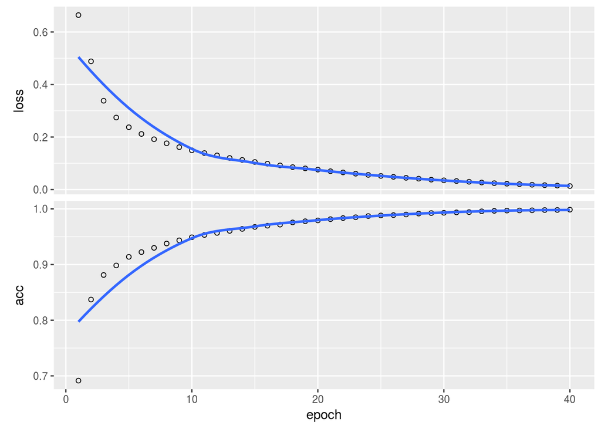

```r
history <- model2 %>%
  fit(train_data_x, train_labels,
  epochs = 40, batch_size = 128, verbose=1
  )

plot(history)
```

```r
predictions <- model2 %>% predict(test_data_x)
table(test_labels, predictions>0.5)
```

```
##
## test_labels FALSE  TRUE
##           0 10688  1812
##           1  2149 10351
```

```r
roc(test_labels, as.vector(predictions))
```

```
##
## Call:
## roc.default(response = test_labels, predictor = as.vector(predictions))
##
## Data: as.vector(predictions) in 12500 controls (test_labels 0) < 12500 cases (test_labels 1).
## Area under the curve: 0.9173
```